# Ass2_DC

Daniel Clark

2023-08-17

```r
library(tidyverse)
library(purrr)
library(ggplot2)
library(leaps)
#library(glmnet)
library(boot)
```

## Task 1.1 - Load data into one file

```r
# Function to load in CSV file
load_single_file = function(filename){
  path = paste0("a2_data/",filename)
  df = read_csv(path, show_col_types=FALSE)
  return(df)
}

# List of CSV files
filelist = list.files(path = "a2_data", pattern = "*.csv")
# Map
df_list = filelist %>% map(load_single_file)

# Merge into one DF
spotify_df = df_list[[1]]
for (i in 2:length(df_list)) {
  spotify_df = bind_rows(spotify_df, df_list[[i]])
}

# Save
saveRDS(spotify_df, file="spotify_df")
```

```r
spotify_df = readRDS("spotify_df")
# Display
head(spotify_df, 15)
```

```
## # A tibble: 15 x 20
##    track_id        artists album_name track_name popularity duration_ms explicit
##    <chr>           <chr>   <chr>      <chr>           <dbl>       <dbl> <lgl>
##  1 5SuOikwiRyPMVo~ Gen Ho~ Comedy     Comedy             73      230666 FALSE
##  2 4qPNDBW1i3p13q~ Ben Wo~ Ghost (Ac~ Ghost - A~         55      149610 FALSE
##  3 1iJBSr7s7jYXzM~ Ingrid~ To Begin ~ To Begin ~         57      210826 FALSE
##  4 6lfxq3CG4xtTiE~ Kina G~ Crazy Ric~ Can't Hel~         71      201933 FALSE
##  5 5vjLSffimiIP26~ Chord ~ Hold On    Hold On            82      198853 FALSE
##  6 01MVOl9KtVTNfF~ Tyrone~ Days I Wi~ Days I Wi~         58      214240 FALSE
##  7 6Vc5wAMmXdKIAM~ A Grea~ Is There ~ Say Somet~         74      229400 FALSE
##  8 1EzrEOXmMH3G43~ Jason ~ We Sing. ~ I'm Yours          80      242946 FALSE
##  9 0IktbUcnAGrvD0~ Jason ~ We Sing. ~ Lucky              74      189613 FALSE
## 10 7k9GuJYLp2Azqo~ Ross C~ Hunger     Hunger             56      205594 FALSE
## 11 4mzP5mHkRvGxdh~ Zack T~ Episode    Give Me Y~         74      244800 FALSE
## 12 5ivF4eQBqJiVL5~ Jason ~ Love Is a~ I Won't G~         69      240165 FALSE
## 13 4ptDJbJl35d7gQ~ Dan Be~ Solo       Solo               52      198712 FALSE
## 14 0X9MxHR1rTkEHD~ Anna H~ Bad Liar   Bad Liar           62      248448 FALSE
## 15 4LbWtBkN82ZRhz~ Chord ~ Hold On (~ Hold On -~         56      188133 FALSE
## # ... with 13 more variables: danceability <dbl>, energy <dbl>, key <dbl>,
## #   loudness <dbl>, mode <dbl>, speechiness <dbl>, acousticness <dbl>,
## #   instrumentalness <dbl>, liveness <dbl>, valence <dbl>, tempo <dbl>,
## #   time_signature <dbl>, track_genre <chr>
```

**a) How many rows and columns?**

```r
size_sum(spotify_df)
```

```
## [1] "[114,000 x 20]"
```

114,000 rows and 20 columns!

**b) What does each row represent?**

Each row represents one song

**c) How many genres in the dataset?**

```r
length(unique(spotify_df$track_genre))
```

```
## [1] 114
```

There are 114 unique genres!

## Task 1.2

Subtask 1 - Data Visualisation

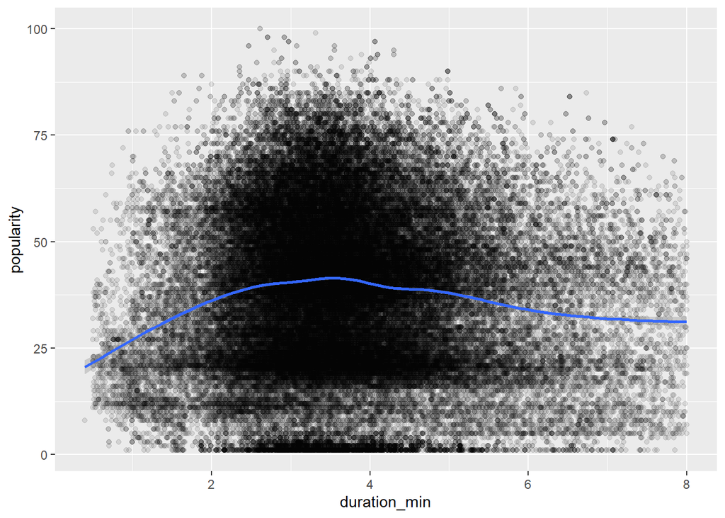

```r
spotify_nonz = filter(spotify_df, popularity>0)
spotify_nonz$duration_min = spotify_nonz$duration_ms / 60 / 1000
# Create Visualisation
b=filter(spotify_nonz, duration_min<=8)
ggplot(b, aes(x=duration_min, y=popularity)) + geom_point(alpha=0.1) + geom_smooth()
```

This visualisation is very interesting because it shows how popular songs tend to be on spotify based on how long they are. The geom_smooth has fit a line to this relationship which shows us that songs tend to be the most popular if they are around 3.5 minutes long.

Subtask 2 - Data cleaning (`spotify_nonz` has already been modified to remove the 0 popularity scores and has converted song duration to minutes)

```r
set.seed(502)


rows_removed = count(spotify_df) - count(spotify_nonz)
```

The number of `rows_removed` when removing observations with a popularity score of 0 was 16020

```r
# More Cleaning
spotify_clean = spotify_nonz %>% select(popularity:duration_min) %>% select(-c(duration_ms, track_genre, key))
```

Here I have removed all the rows without any meaningful numeric interpretation. For example, track_ID is not going to be a helpful measure for predicting its popularity, and neither is anything else with a huge number of factors, including Artist, Album, Genre, Key etc. I have also removed the duration in milliseconds column, as the duration in minutes attribute already contains this relevant information.

Create linear Model

```r
# Code from Lab 4
# Crossvalidation code
allyhat<-function(xtrain, ytrain, xtest,lambdas,nvmax=50){
  n<-nrow(xtrain)
  yhat<-matrix(nrow=nrow(xtest),ncol=length(lambdas))
  search<-regsubsets(xtrain,ytrain, nvmax=nvmax, method="back")
  summ<-summary(search)
  for(i in 1:length(lambdas)){
    penMSE<- n*log(summ$rss)+lambdas[i]*(1:nvmax)
    best<-which.min(penMSE)  #lowest penMSE
    betahat<-coef(search, best) #coefficients
    xinmodel<-cbind(1,xtest)[,summ$which[best,]] #predictors in that model
    yhat[,i]<-xinmodel%*%betahat
  }
  yhat
}

# Set y
mf<-model.frame(popularity~.^2, data=spotify_clean)
X<-model.matrix(popularity~.^2, mf)[,-1]
y = spotify_clean$popularity

n<-nrow(X)
folds<-sample(rep(1:10,length.out=n))
lambdas<-c(0,2,4,6,8,10,12)
fitted<-matrix(nrow=n,ncol=length(lambdas))
for(k in 1:10){
  train<- (1:n)[folds!=k]
  test<-(1:n)[folds==k]
  fitted[test,]<-allyhat(X[train,],y[train],X[test,],lambdas)
}
MSPE = colMeans((y-fitted)^2)
print(MSPE)
```

```
## [1] 329.9302 329.9341 329.9524 330.0518 330.0453 330.1254 330.1135
```

```r
fitted = as.data.frame(fitted)
fitted$y_val = y
```

Subtask 3 - Justify Model Selection

I have chosen to select a linear regression model because the `popularity` is a numeric response variable, and we can use linear regression based on the remaining 13 numeric/logical attributes to build a convincing model using linear regression. We can assume independence because each song is unique, and if we wanted to (if Liza had asked us to) we could check other assumptions of this model including checking for equality of variance and cook’s distance plot for significant observations.

I have chosen to base this model only on the numeric variables in the spotify data, as the non-numeric variables had too many levels to give us any meaningful insight, and would only have needlessly complicated the data. I was tempted to leave in the ‘genre’ attribute but decided to remove it because there are still so many levels that it would complicate the model too much for the small possible gain it would give us.

The optimal lambda found by cross-validation is 0. This means that we do not penalise at all having extra attributes in our model, so fitting the final model will give us a model with all parameters that I have left in being active.

```r
# As our optimal lambda value is 0, there is no need to use regsubsets to find different parameter sets.
model = lm(popularity~., data=spotify_clean)

summary(model)$coefficients[,1]
```

```
##      (Intercept)     explicitTRUE     danceability           energy
##     49.515787257      4.280479057      7.063735345     -7.494504326
##         loudness             mode      speechiness     acousticness
##      0.237971740     -0.656112701    -20.976560388     -1.368109258
## instrumentalness         liveness          valence            tempo
##    -11.785471738     -2.113008192     -7.480148138     -0.006869304
##   time_signature     duration_min
##      0.695261953     -0.445676860
```

Subtask 4 - Clearly report your final model

My final model is $Popularity = \beta_0 + \sum_{i=1}^n \beta_{i}X_{i} + \epsilon$, where $\epsilon ^{iid} N(0,\sigma^{2})$, n is the number of explanatory variables = 13, $\beta_{i}$ is the ith estimate as shown in the summary table above, and $X_{i}$ is the value of the corresponding attribute.

## Task 1.3

Choose song from spotify dataset and craft a 95% prediction interval for uncertainty:

```r
set.seed(502)
song_num = sample(1:length(spotify_clean$popularity), 1)
song_values = (spotify_clean[song_num,])
knitr::kable(spotify_nonz[song_num,])
```

| track_id | artists | album_name | track_name | popularity | duration_ms | explicit | danceability | energy | key | loudness | mode | speechiness | acousticness | instrumentalness | liveness | valence | tempo | time_signature | track_genre | duration_min |
| --- | --- | --- | --- | --- | --- | --- | --- | --- | --- | --- | --- | --- | --- | --- | --- | --- | --- | --- | --- | --- |
| 7j56HrjR9cGzvekvZY3Faz | Fitz and The Tantrums | Fitz and The Tantrums | HandClap | 65 | 193253 | FALSE | 0.636 | 0.836 | 8 | -3.004 | 1 | 0.0427 | 0.00609 | 0.000157 | 0.0828 | 0.715 | 139.956 | 4 | indie-pop | 3.220883 |

I have set my seed and then selected a song at random. I don’t know the song, but it turns out I do know this artist! This makes me think it might be a fairly popular song. Now to construct a confidence interval.

Bootstrapping

```r
# Adapted from code in the extra bits by Liza Bolton
predict_spotify = function(data, i){
  model = lm(popularity~., data=spotify_clean[i,])
  predict.lm(model, song_values, interval = "none") + sample(resid(model),1) # add sampled residual
}

bootstraps = boot(spotify_clean, predict_spotify, R = 1000)

pred_int = round(t(quantile(bootstraps$t, c(0.025, 0.975))),2)

knitr::kable(pred_int)
```

| 2.5% | 97.5% |
| --- | --- |
| 1.21 | 76.23 |

## References:

https://canvas.auckland.ac.nz/courses/89825/files/11451795?module_item_id=1927869&fd_cookie_set=1, Liza Bolton, accessed 23/08/2023